# 03_phylogeny.md

Gulnara Tagridzhanova

26/03/2025

## 1. ITS based phylogeny

### 1.1. Assemble dataset

- Used sequences from [Muggia et al. 2020](https://www.sciencedirect.com/science/article/pii/S1055790320300932#s0075). They are listed in the table S1, which I saved as `analysis_and_temp_files/03_phylogeny/muggia.txt`
- I manually subsampled them so that every OTU had maximum 5 sequences
- Added Myrmecia (PQ154957.1) as an outgroup
- Downloaded ITS sequences from the NCBI

#### Identify ITS in the assemblies

- Used AJ969550.1 as a query

```r
source package /tsl/software/testing/bin/blast+-2.9.0
blastn \
 -subject analysis_and_temp_files/05_genome_annotation/GTX0536_nuclear_final_sort.fasta \
 -query analysis_and_temp_files/03_phylogeny/its_query.fasta \
 -outfmt 6 \
 -evalue 1e-25 \
 -out analysis_and_temp_files/03_phylogeny/GTX0536_its.blast

blastn \
 -subject data/SL0000003.fasta \
 -query analysis_and_temp_files/03_phylogeny/its_query.fasta \
 -outfmt 6 \
 -evalue 1e-25 \
 -out analysis_and_temp_files/03_phylogeny/SL0000003_its.blast
```

- Extracted ITS from the contig GTX0536_15 (2399373-2400063) and, for SL0000003, from OZ234921.1:1387879-1387378

```r
source package aeee87c4-1923-4732-aca2-f2aff23580cc

samtools faidx analysis_and_temp_files/05_genome_annotation/GTX0536_nuclear_final_sort.fasta GTX0536_15:2399373-2400063 > analysis_and_temp_files/03_phylogeny/GTX0536_its.fa

samtools faidx data/SL0000003.fasta OZ234921.1:1387378-1387879 -i > analysis_and_temp_files/03_phylogeny/SL0000003_its.fa
```

#### Reconstruct phylogeny

- Concatenate and aligned everything. Trimmed the alignment to remove positions with >20% gaps

```r
cat analysis_and_temp_files/03_phylogeny/SL0000003_its.fa analysis_and_temp_files/03_phylogeny/GTX0536_its.fa analysis_and_temp_files/03_phylogeny/its_ncbi.fasta > analysis_and_temp_files/03_phylogeny/its_all.fasta

source package /tgac/software/testing/bin/mafft-7.271
source package /tsl/software/testing/bin/trimal-1.2

mafft --maxiterate 1000 --genafpair --thread 10  analysis_and_temp_files/03_phylogeny/its_all.fasta >  analysis_and_temp_files/03_phylogeny/its_all_aligned.fa

trimal -in analysis_and_temp_files/03_phylogeny/its_all_aligned.fa -out analysis_and_temp_files/03_phylogeny/its_all_aligned.phyl -gt 0.2 -phylip
```

- Tree with IQTree

```r
source package /tgac/software/testing/bin/iqtree-2.2.2.2
iqtree2 -s analysis_and_temp_files/03_phylogeny/its_all_aligned.phyl  -B 10000 -T AUTO --threads-max 10
```

#### Process the tree

- Rename tree tips

```r
library(ape)
library(ggtree)
tree<-read.tree("../analysis_and_temp_files/03_phylogeny/its_all_aligned.phyl.contree")

itsdf<-read.delim2("../analysis_and_temp_files/03_phylogeny/its_table.txt")
itsdf$old<-paste0(itsdf$ITS,".1")
itsdf2<-data.frame("Specimen.Label"=c("SL0000003","GTX0536"),
                   "OTU"=c("SL0000003","GTX0536"),
                   "ITS"=c("OZ234921.1", "GTX0536_15"),
                   "old"=c("OZ234921.1", "GTX0536_15"))
itsdf<-rbind(itsdf,itsdf2)
tree$tip.label<-itsdf[[1]][match(tree$tip.label, itsdf[[4]])]
ape::write.tree(tree, file='../analysis_and_temp_files/03_phylogeny/its_all_aligned.phyl.renamed.contree')
```

- Since the tree has >300 tips, visualizing it in R is cumbersome. moved to iTOL instead

## 2. Phylogenomics

#### Assemble dataset

- Got reference genomes. The list is in `analysis_and_temp_files/03_phylogeny/reference_genomes.csv`
  - Used the same reference algal genomes which I previously got together as a part of my previous paper
  - This included Chara as an outgroup
  - Added the four Trebouxia MAGs isolated from Xanthoria metagenomes in the aforementioned paper

```r
library(kableExtra)
t<-read.csv("../analysis_and_temp_files/03_phylogeny/reference_genomes.csv")
t %>%  kable(format = "html", col.names = colnames(t)) %>%
  kable_styling() %>%
  kableExtra::scroll_box(width = "100%", height = "300px")
```

[output not shown]

- Copied everything in one folder

```r
 mkdir analysis_and_temp_files/03_phylogeny/orthofinder_input
cp ../01_Xanthoria_metagenomics/data/ref_genomes/* analysis_and_temp_files/03_phylogeny/orthofinder_input
```

- Added the proteome from our two Trebouxia genomes

```r
cp analysis_and_temp_files/05_genome_annotation/SL0000003_pred/annotate_results/Trebouxia_SL0000003_SL0000003.proteins.fa analysis_and_temp_files/03_phylogeny/orthofinder_input/

cp analysis_and_temp_files/05_genome_annotation/GTX0536_pred2/update_results/Trebouxia_sp._A48.proteins.fa analysis_and_temp_files/03_phylogeny/orthofinder_input/
```

#### Orthofinder: inital run

```r
source package fc91613f-1095-4f67-b5aa-b86d702b36da
/software/fc91613f-1095-4f67-b5aa-b86d702b36da/bin/orthofinder  -f analysis_and_temp_files/03_phylogeny/orthofinder_input/
```

```
OrthoFinder assigned 288049 genes (90.3% of total) to 19612 orthogroups. Fifty percent of all genes were in orthogroups with 24 or more genes (G50 was 24) and were contained in the largest 4094 orthogroups (O50 was 4094). There were 333 orthogroups with all species present and 37 of these consisted …

333 trees had all species present and will be used by STAG to infer the species tree
```

#### Re-ranning Orthofinder with the addition of T. lynnae

- Will add to our phylogenomic additional genome of Trebouxia lynnae
- NCBI contains 3 assemblies, but no genome annotation is available
- Ran BUSCO on the genome JAVLRR01, which is the only one published

```r
mkdir analysis_and_temp_files/03_phylogeny/Treblynn_busco
source package ca890cd7-f81d-4c22-9f4a-5b40ab671c79
source package 85f2de80-4bd0-48dc-9303-bba1a19206e4
export AUGUSTUS_CONFIG_PATH=../02_long_read_assemblies/analysis_and_temp_files/02_binning/tmp_augustus/config
busco -i data/ref_genomes/GCA_042018865.1_Tlynv2_genomic.fna  -o Treblynn --out_path analysis_and_temp_files/03_phylogeny/Treblynn_busco  -m  genome -l /tsl/data/busco_lineages/chlorophyta_odb10 --offline -f -c 20
```

- Saved all fastas into a single file

```r
cat analysis_and_temp_files/03_phylogeny/Treblynn_busco/Treblynn/run_chlorophyta_odb10/busco_sequences/*/*.faa > analysis_and_temp_files/03_phylogeny/Treblynn_busco/Treblynn_busco.faa
```

- Re-ran Orthofinder with the new genome

```r
source package fc91613f-1095-4f67-b5aa-b86d702b36da
/software/fc91613f-1095-4f67-b5aa-b86d702b36da/bin/orthofinder -f analysis_and_temp_files/03_phylogeny/Treblynn_busco -b analysis_and_temp_files/03_phylogeny/orthofinder_input/OrthoFinder/Results_Apr13/WorkingDirectory
```

```
OrthoFinder assigned 289558 genes (90.4% of total) to 19599 orthogroups. Fifty percent of all genes were in orthogroups with 25 or more genes (G50 was 25) and were contained in the largest 4068 orthogroups (O50 was 4068). There were 328 orthogroups with all species present and 36 of these consisted …

328 trees had all species present and will be used by STAG to infer the species tree
```

#### Visualize

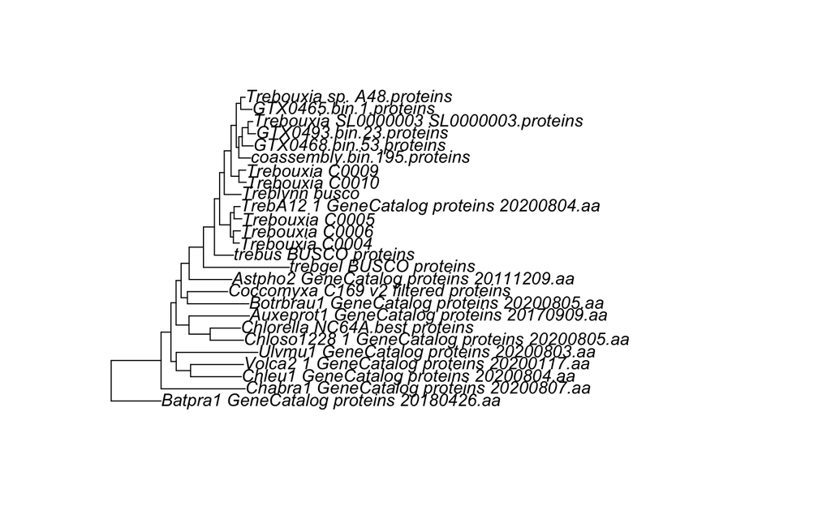

```r
library(ape)
library(ggtree)
tree<-read.tree("../analysis_and_temp_files/03_phylogeny/orthofinder_input/SpeciesTree_rooted_node_labels.txt")
plot(tree)
```

## 3. Orthogroups

```r
library(UpSetR)
ortho<-read.delim2("../analysis_and_temp_files/03_phylogeny/orthofinder_input/Orthogroups.GeneCount.tsv")

#rename relevant
colnames(ortho)[colnames(ortho)=="Trebouxia_SL0000003_SL0000003.proteins" ] <- "Trebouxia sp. SL0000003"
colnames(ortho)[colnames(ortho)=="Trebouxia_sp._A48.proteins" ] <- "Trebouxia sp. A48"
colnames(ortho)[colnames(ortho)=="Trebouxia_C0010" ] <- "Trebouxia sp. C0010"
colnames(ortho)[colnames(ortho)=="Trebouxia_C0004" ] <- "Trebouxia sp. C0004"
colnames(ortho)[colnames(ortho)=="Trebouxia_C0005" ] <- "Trebouxia sp. C0005"
colnames(ortho)[colnames(ortho)=="Trebouxia_C0006" ] <- "Trebouxia sp. C0006"
colnames(ortho)[colnames(ortho)=="Trebouxia_C0009" ] <- "Trebouxia sp. C0009"
colnames(ortho)[colnames(ortho)=="TrebA12_1_GeneCatalog_proteins_20200804.aa" ] <- "Trebouxia sp. A1-2"
colnames(ortho)[colnames(ortho)=="Treblynn_busco" ] <- "Trebouxia lynnae"

##plot
selected_species <- colnames(ortho)[c(21,20,18,19,17,16,15,14)]
ortho[ortho > 0] <- 1

pdf(file="../results/upset.pdf", onefile=FALSE)
upset(ortho, nsets = ncol(ortho), sets = rev(selected_species), keep.order = T, order.by = "freq",nintersects=20)
dev.off()
```

```r
ggsave("../results/upset.pdf", height = 3 * 5.5, width = 4.5 * 5)



pdf("../results/upset.pdf", onefile=FALSE,height=3,width=8)
upset(ortho, nsets = ncol(ortho), sets = rev(selected_species), keep.order = T, order.by = "freq",nintersects=20,mb.ratio=c(0.5,0.5))
dev.off()
```

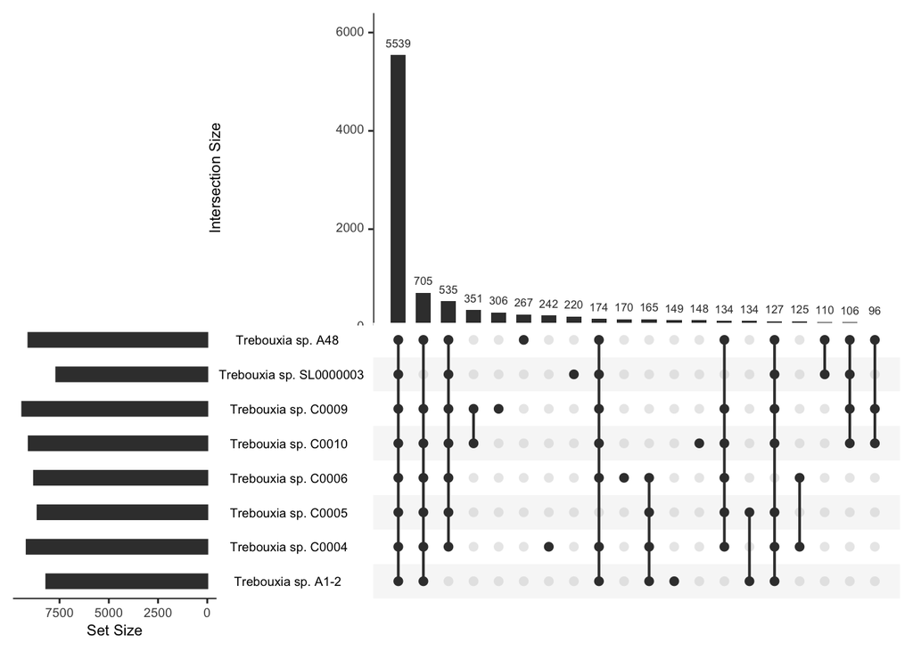

```r
upset(ortho, nsets = ncol(ortho), sets = rev(selected_species), keep.order = T, order.by = "freq",nintersects=20,mb.ratio=c(0.5,0.5))
```

- How many orthogroups shared between our genome and SL0000003

```r
ortho %>% mutate(xantho =
      case_when(`Trebouxia sp. SL0000003`==1 & `Trebouxia sp. A48`==1 ~ "both",
               `Trebouxia sp. SL0000003`==1 & `Trebouxia sp. A48`==0 ~ "SL",
               `Trebouxia sp. SL0000003`==0 & `Trebouxia sp. A48`==1 ~ "A48",
               `Trebouxia sp. SL0000003`==0 & `Trebouxia sp. A48`==0 ~ "neither")) %>%
  group_by(xantho) %>% dplyr::summarize(n=n())
```

```
## # A tibble: 4 × 2
##   xantho      n
##   <chr>   <int>
## 1 A48      1864
## 2 SL        449
## 3 both     7216
## 4 neither 10070
```

- What genes and gene functions are in the OGs that are unique to our genome and to our genome + SL000003 compared to other genomes

```r
ortho_genes<-read.delim2("../analysis_and_temp_files/03_phylogeny/orthofinder_input/Orthogroups.tsv")
ann <- read.delim2("../analysis_and_temp_files/02_genome_annotation/GTX0536_pred2/Trebouxia_sp._A48.annotations.reduced.txt")

only_our <- ortho_genes %>% select(Orthogroup,TrebA12_1_GeneCatalog_proteins_20200804.aa,Trebouxia_C0004,
   Trebouxia_C0005,Trebouxia_C0006,Trebouxia_C0009,Trebouxia_C0010,
   Trebouxia_SL0000003_SL0000003.proteins, Trebouxia_sp._A48.proteins) %>%
  filter(Trebouxia_sp._A48.proteins!="",
         TrebA12_1_GeneCatalog_proteins_20200804.aa=="",
         Trebouxia_C0004=="",Trebouxia_C0005=="",
         Trebouxia_C0006=="",Trebouxia_C0009=="",
         Trebouxia_C0010=="",Trebouxia_SL0000003_SL0000003.proteins=="") %>%
  select(Orthogroup,Trebouxia_sp._A48.proteins) %>%
  separate_rows(Trebouxia_sp._A48.proteins,sep=", ") %>%
  mutate(Trebouxia_sp._A48.proteins = str_replace(Trebouxia_sp._A48.proteins,"FUN","GTX0536PRED")) %>%
  left_join(ann,by=c("Trebouxia_sp._A48.proteins"="TranscriptID"))

only_two <- ortho_genes %>% select(Orthogroup,TrebA12_1_GeneCatalog_proteins_20200804.aa,Trebouxia_C0004,
   Trebouxia_C0005,Trebouxia_C0006,Trebouxia_C0009,Trebouxia_C0010,
   Trebouxia_SL0000003_SL0000003.proteins, Trebouxia_sp._A48.proteins) %>%
  filter(Trebouxia_sp._A48.proteins!="",
         TrebA12_1_GeneCatalog_proteins_20200804.aa=="",
         Trebouxia_C0004=="",Trebouxia_C0005=="",
         Trebouxia_C0006=="",Trebouxia_C0009=="",
         Trebouxia_C0010=="",Trebouxia_SL0000003_SL0000003.proteins!="") %>%
  select(Orthogroup,Trebouxia_sp._A48.proteins) %>%
  separate_rows(Trebouxia_sp._A48.proteins,sep=", ") %>%
  mutate(Trebouxia_sp._A48.proteins = str_replace(Trebouxia_sp._A48.proteins,"FUN","GTX0536PRED")) %>%
  left_join(ann,by=c("Trebouxia_sp._A48.proteins"="TranscriptID"))


write.table(only_two, "../results/OG_only_two_genomes.txt",col.names = T, row.names = F, quote = F,sep="\t")
write.table(only_our, "../results/OG_only_our_genome.txt",col.names = T, row.names = F, quote = F,sep="\t")
```